# Debug Kotlin Flow using IntelliJ IDEA – tutorial

This tutorial demonstrates how to create Kotlin Flow and debug it using IntelliJ IDEA.

The tutorial assumes you have prior knowledge of the coroutines and flow concepts.

## Create a Kotlin flow

Create a Kotlin [flow](https://kotlinlang.org/api/kotlinx.coroutines/kotlinx-coroutines-core/kotlinx.coroutines.flow/flow.html) with a slow emitter and a slow collector:

1. Open a Kotlin project in IntelliJ IDEA. If you don't have a project, create one.
2. To use the `kotlinx.coroutines` library in a Gradle project, add the following dependency to `build.gradle(.kts)`:

   ```
   dependencies {
       implementation("org.jetbrains.kotlinx:kotlinx-coroutines-core:1.11.0")
   }
   ```

   ```
   dependencies {
       implementation 'org.jetbrains.kotlinx:kotlinx-coroutines-core:1.11.0'
   }
   ```

   For other build systems, see instructions in the [`kotlinx.coroutines` README](https://github.com/Kotlin/kotlinx.coroutines#using-in-your-projects).
3. Open the `Main.kt` file in `src/main/kotlin`.

   The `src` directory contains Kotlin source files and resources. The `Main.kt` file contains sample code that will print `Hello World!`.
4. Create the `simple()` function that returns a flow of three numbers:
   - Use the [`delay()`](https://kotlinlang.org/api/kotlinx.coroutines/kotlinx-coroutines-core/kotlinx.coroutines/delay.html) function to imitate CPU-consuming blocking code. It suspends the coroutine for 100 ms without blocking the thread.
   - Produce the values in the `for` loop using the [`emit()`](https://kotlinlang.org/api/kotlinx.coroutines/kotlinx-coroutines-core/kotlinx.coroutines.flow/-flow-collector/emit.html) function.

   ```
   import kotlinx.coroutines.*
   import kotlinx.coroutines.flow.*
   import kotlin.system.*

   fun simple(): Flow<Int> = flow {
       for (i in 1..3) {
           delay(100)
           emit(i)
       }
   }
   ```

5. Change the code in the `main()` function:
   - Use the [`runBlocking()`](https://kotlinlang.org/api/kotlinx.coroutines/kotlinx-coroutines-core/kotlinx.coroutines/run-blocking.html) block to wrap a coroutine.
   - Collect the emitted values using the [`collect()`](https://kotlinlang.org/api/kotlinx.coroutines/kotlinx-coroutines-core/kotlinx.coroutines.flow/collect.html) function.
   - Use the [`delay()`](https://kotlinlang.org/api/kotlinx.coroutines/kotlinx-coroutines-core/kotlinx.coroutines/delay.html) function to imitate CPU-consuming code. It suspends the coroutine for 300 ms without blocking the thread.
   - Print the collected value from the flow using the [`println()`](https://kotlinlang.org/api/latest/jvm/stdlib/kotlin.io/println.html) function.

   ```
   fun main() = runBlocking {
       simple()
           .collect { value ->
               delay(300)
               println(value)
           }
   }
   ```

6. Build the code by clicking Build Project.

[figure not shown]

## Debug the coroutine

1. Set a breakpoint at the line where the `emit()` function is called:

[figure not shown]

2. Run the code in debug mode by clicking Debug next to the run configuration at the top of the screen.

[figure not shown]

   The Debug tool window appears:
   - The Frames tab contains the call stack.
   - The Variables tab contains variables in the current context. It tells us that the flow is emitting the first value.
   - The Coroutines tab contains information on running or suspended coroutines.

[figure not shown]

3. Resume the debugger session by clicking Resume Program in the Debug tool window. The program stops at the same breakpoint.

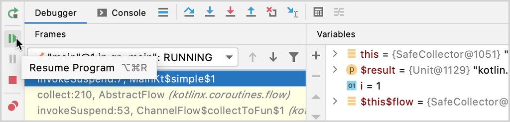

   Now the flow emits the second value.

[figure not shown]

### Optimized-out variables

If you use `suspend` functions, in the debugger, you might see the "was optimized out" text next to a variable's name:

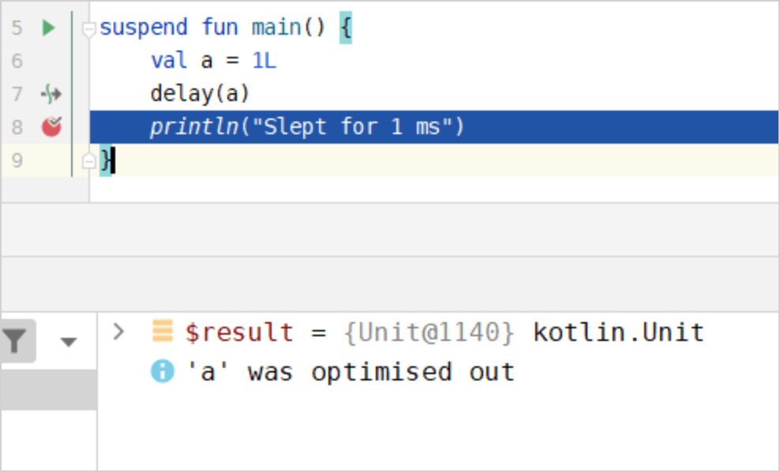

This text means that the variable's lifetime was decreased, and the variable doesn't exist anymore. It is difficult to debug code with optimized variables because you don't see their values. You can disable this behavior with the `-Xdebug` compiler option.

## Add a concurrently running coroutine

1. Open the `Main.kt` file in `src/main/kotlin`.
2. Enhance the code to run the emitter and collector concurrently:
   - Add a call to the [`buffer()`](https://kotlinlang.org/api/kotlinx.coroutines/kotlinx-coroutines-core/kotlinx.coroutines.flow/buffer.html) function to run the emitter and collector concurrently. `buffer()` stores emitted values and runs the flow collector in a separate coroutine.

   ```
   fun main() = runBlocking<Unit> {
       simple()
           .buffer()
           .collect { value ->
               delay(300)
               println(value)
           }
   }
   ```

3. Build the code by clicking Build Project.

## Debug a Kotlin flow with two coroutines

1. Set a new breakpoint at `println(value)`.
2. Run the code in debug mode by clicking Debug next to the run configuration at the top of the screen.

[figure not shown]

   The Debug tool window appears.

   In the Coroutines tab, you can see that there are two coroutines running concurrently. The flow collector and emitter run in separate coroutines because of the `buffer()` function. The `buffer()` function buffers emitted values from the flow. The emitter coroutine has the RUNNING status, and the collector coroutine has the SUSPENDED status.
3. Resume the debugger session by clicking Resume Program in the Debug tool window.

[figure not shown]

   Now the collector coroutine has the RUNNING status, while the emitter coroutine has the SUSPENDED status.

   You can dig deeper into each coroutine to debug your code.

16 June 2026

© 2010–2026 JetBrains s.r.o. and Kotlin Programming Language contributors  
Licensed under the Apache License, Version 2.0.  
https://kotlinlang.org/docs/debug-flow-with-idea.html